# Intro to R

## Setting axis

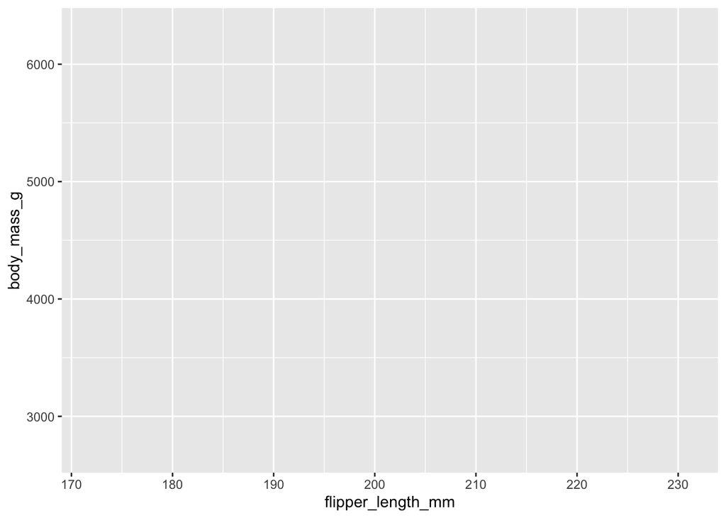

```r
ggplot(  data = penguins,
         mapping = aes(x = flipper_length_mm, y = body_mass_g))
```

## Adding data

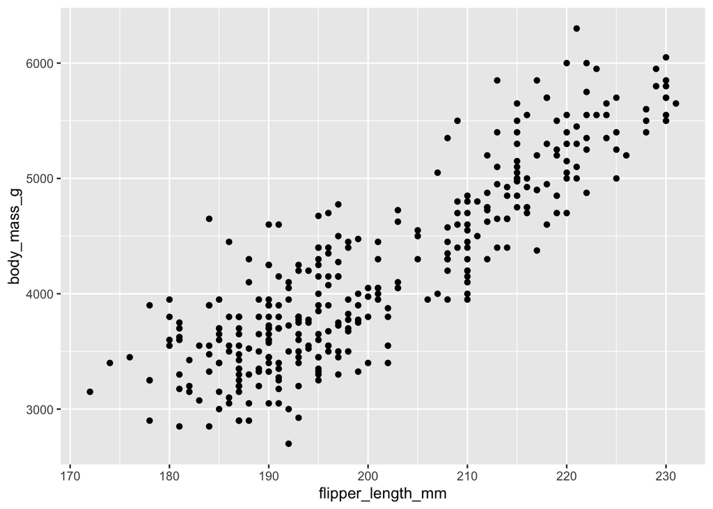

```r
ggplot(  data = penguins,
        mapping = aes(x = flipper_length_mm, y = body_mass_g)) +
  geom_point()
```

## Coloring by species

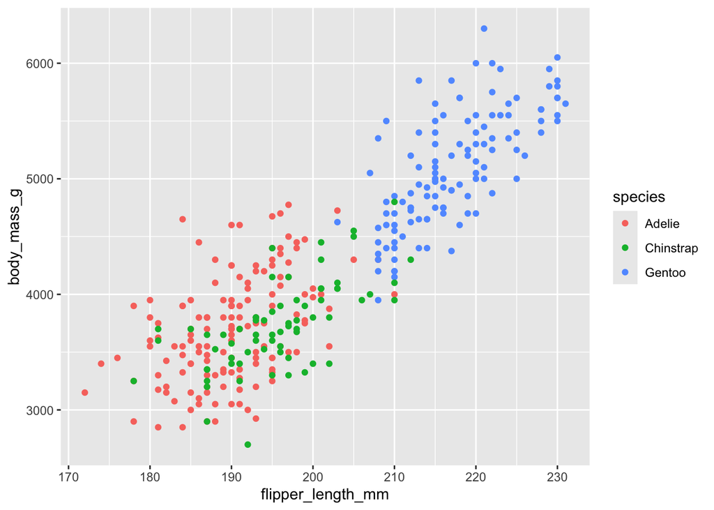

```r
ggplot(  data = penguins,
        mapping = aes(x = flipper_length_mm, y = body_mass_g, color=species)) +
  geom_point()
```

## Adding local lm lines

```r
ggplot(
  data = penguins,
  mapping = aes(x = flipper_length_mm, y = body_mass_g, color = species)
) +
  geom_point() +
  geom_smooth(method = "lm")
```

## Adding local lm lines

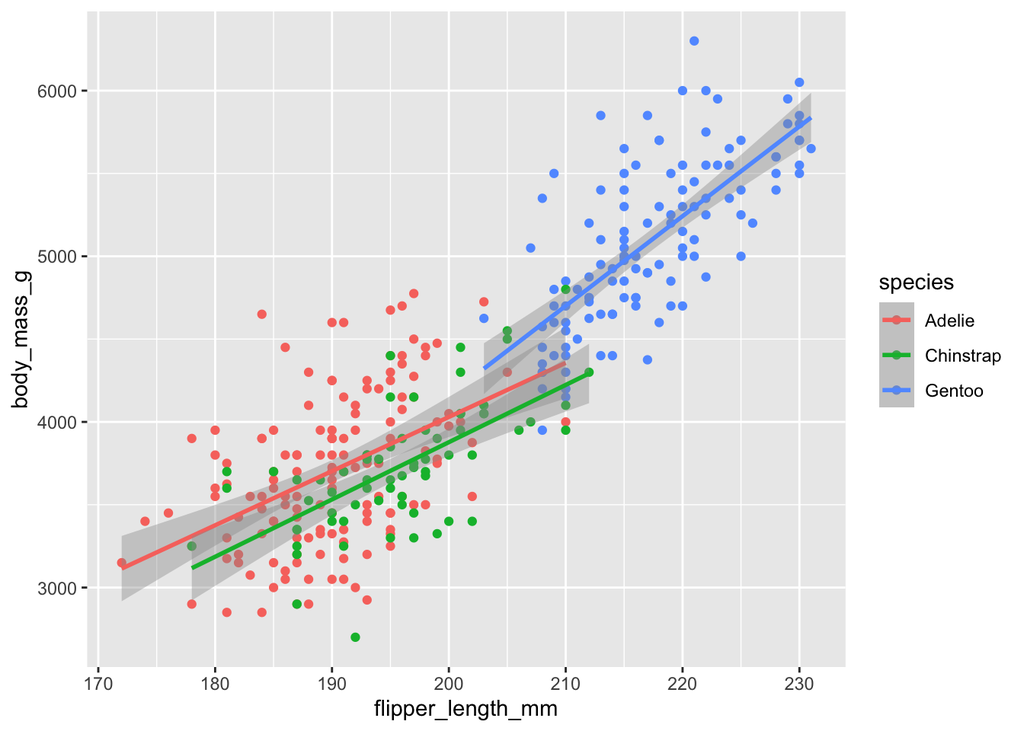

## Adding global lm line

```r
ggplot(
  data = penguins,
  mapping = aes(x = flipper_length_mm, y = body_mass_g)
) +
  geom_point(mapping = aes(color = species)) +
  geom_smooth(method = "lm")
```

## Adding global lm line

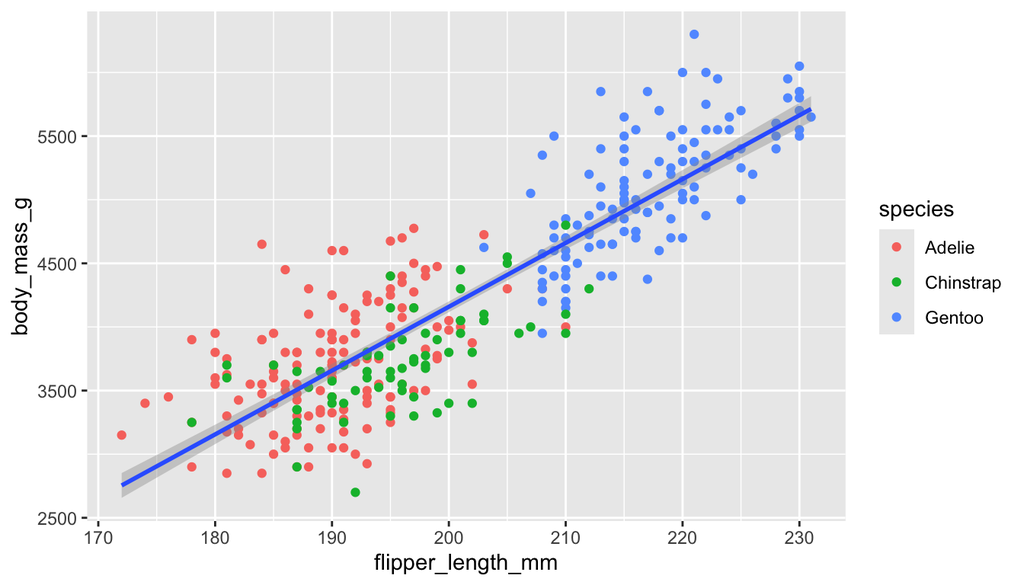

## Change colors and add title and subtitle

```r
ggplot(
  data = penguins,
  mapping = aes(x = flipper_length_mm, y = body_mass_g)
) +
  geom_point(aes(color = species, shape = species)) +
  geom_smooth(method = "lm") +
  labs(
    title = "Body mass and flipper length",
    subtitle = "Dimensions for Adelie, Chinstrap, and Gentoo Penguins",
    x = "Flipper length (mm)", y = "Body mass (g)",
    color = "Species", shape = "Species"
  ) +
  scale_color_colorblind()
```

## Change colors and add title and subtitle

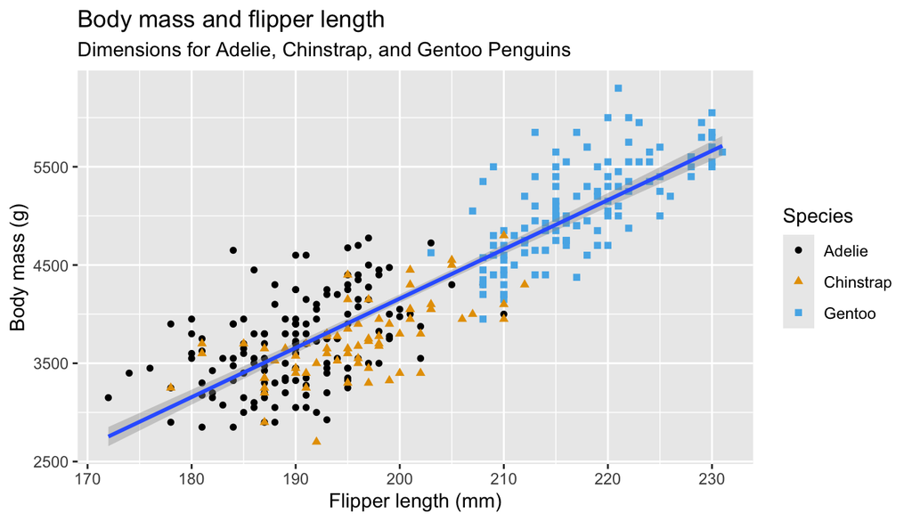

## Add facets

```r
ggplot(
  data = penguins,
  mapping = aes(x = flipper_length_mm, y = body_mass_g)
) +
  geom_point(aes(color = species, shape = species)) +
  geom_smooth(method = "lm") +
  facet_wrap(vars(island)) +
  labs(
    title = "Body mass and flipper length",
    subtitle = "Dimensions for Adelie, Chinstrap, and Gentoo Penguins",
    x = "Flipper length (mm)", y = "Body mass (g)",
    color = "Species", shape = "Species"
  ) +
  scale_color_colorblind()
```

## Add facets

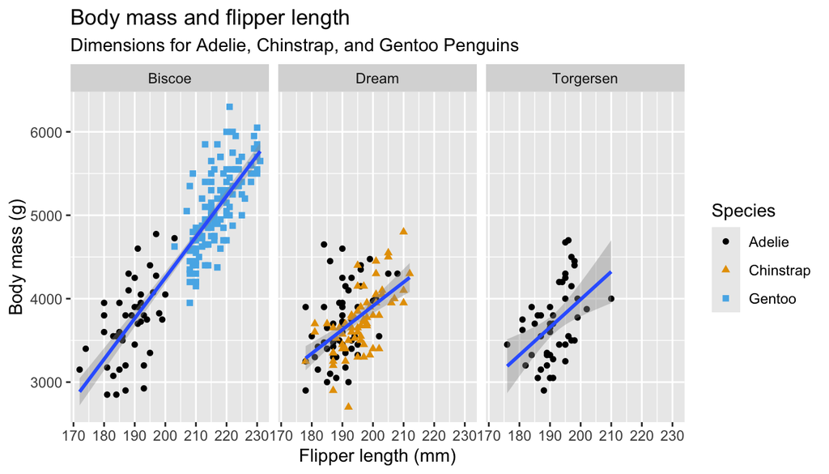

## Data and mapping are the first two arguments by default

```r
ggplot(
  penguins,
  aes(x = flipper_length_mm, y = body_mass_g)
) +
  geom_point(aes(color = species, shape = species)) +
  geom_smooth(method = "lm") +
  labs(
    title = "Body mass and flipper length",
    subtitle = "Dimensions for Adelie, Chinstrap, and Gentoo Penguins",
    x = "Flipper length (mm)", y = "Body mass (g)",
    color = "Species", shape = "Species"
  ) +
  scale_color_colorblind()
```

[output not shown]

## A little about visualizing categorical variables

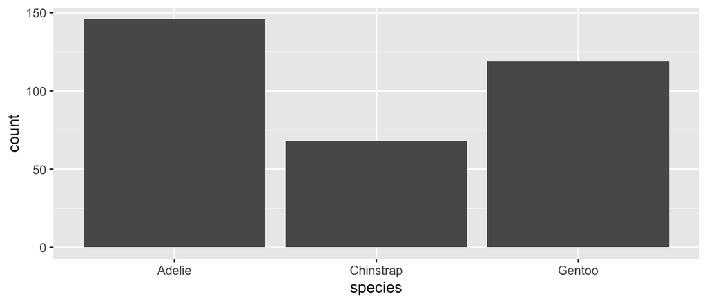

```r
ggplot(penguins, aes(x = species)) +
  geom_bar()
```

## Ordering columns by number of elements

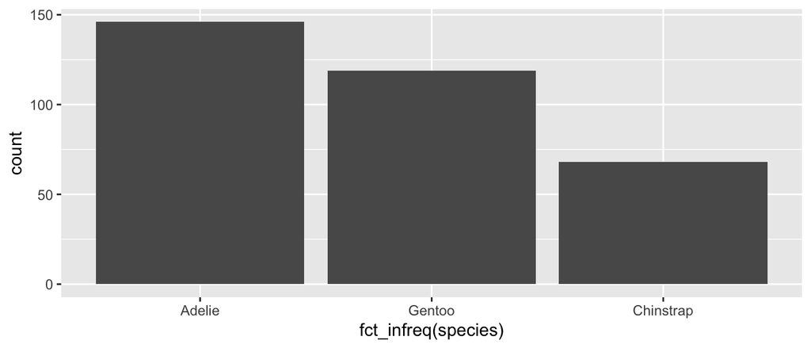

```r
ggplot(penguins, aes(x = fct_infreq(species))) +
  geom_bar()
```

## Bindwidths can be assigned to numerical variables to visualize them as histograms

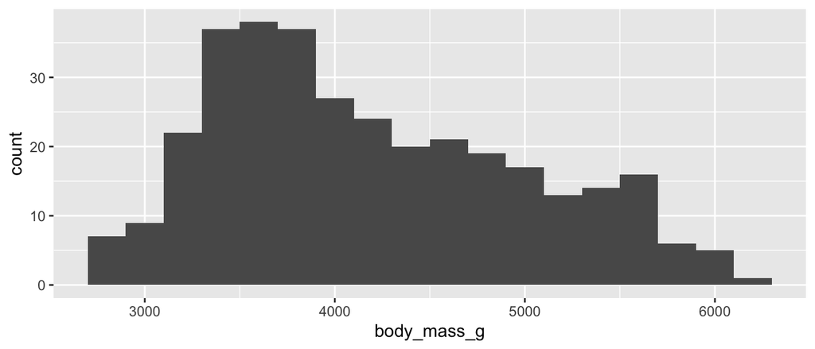

```r
ggplot(penguins, aes(x = body_mass_g)) +
  geom_histogram(binwidth = 200)
```

## You can save plots with ggsave

```r
p <- ggplot(penguins, aes(x = body_mass_g)) +
  geom_histogram(binwidth = 200)

ggsave("Figures/amazing_inspired_beautiful_plot.svg",
       plot = p,
       device = "svg")
```

# Principal component analysis (PCA)

## Principal component analysis (PCA)

It is a linear dimensionality reduction technique.

This means that it aims to reduce the number of dimensions that describe the dataset while retaining as much information as possible.

For example, the flipper length of penguins kind of correlate with their body mass:

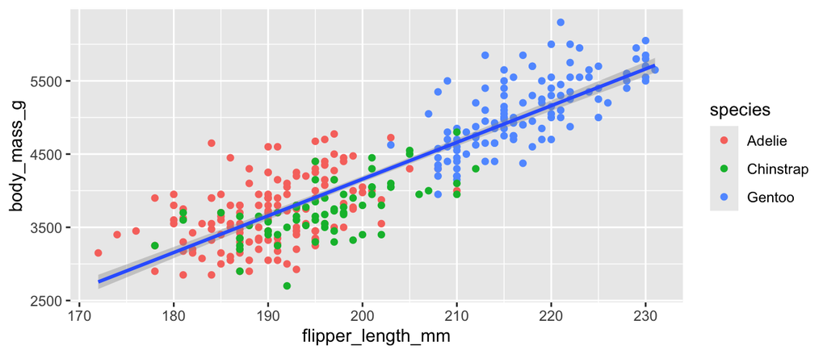

## Using PCA to reduce dimensions

We can use a PCA to define principal components, which are single values that retain information about multiple dimensions, such as flipper length and body mass.

In practice, before doing PCA you must:

- remove any NA values
- select numerical columns and/or turn categorical columns to factors
- center and scale all numerical columns

```r
penguins <- penguins %>% drop_na()
penguins_numeric <- select_if(penguins, is.numeric)
pca_result <- prcomp(penguins_numeric, center=TRUE, scale. = TRUE)
```

## Let’s take a look at the results

Each of the original numeric colums correlates and contributes to each of the PC by different amounts.

```r
pca_result
```

```
Standard deviations (1, .., p=5):
[1] 1.6599646 1.0003787 0.8814529 0.6070960 0.3134248

Rotation (n x k) = (5 x 5):
                          PC1          PC2         PC3         PC4        PC5
bill_length_mm     0.45154157 -0.099588121 -0.59421451 -0.64187447  0.1452539
bill_depth_mm     -0.39787095 -0.006023954 -0.79813107  0.42457217 -0.1561656
flipper_length_mm  0.57729286  0.039128180 -0.01101946  0.23341049 -0.7814090
body_mass_g        0.54662169 -0.100617749 -0.06856617  0.59425418  0.5772707
year               0.07580637  0.989136478 -0.07122618 -0.01082346  0.1033059
```

## We can visualize it like this

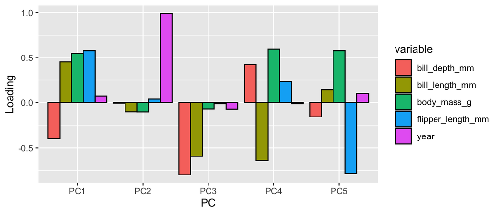

```r
pca_df <- as.data.frame(pca_result$rotation)
pca_df <- pca_df %>% mutate(variable=rownames(pca_df))
pca_tidy <- pivot_longer(pca_df, cols = -variable, names_to = "PC",
                         values_to = "Loading")
ggplot(pca_tidy, aes(x = PC, y = Loading, fill = variable)) +
  geom_bar(stat = "identity", position = "dodge", color = "black")
```

## Each PC explains a certain amount of variability

```r
summary(pca_result)
```

```
Importance of components:
                          PC1    PC2    PC3     PC4     PC5
Standard deviation     1.6600 1.0004 0.8815 0.60710 0.31342
Proportion of Variance 0.5511 0.2001 0.1554 0.07371 0.01965
Cumulative Proportion  0.5511 0.7512 0.9066 0.98035 1.00000
```

## Let’s look at this with ggplot

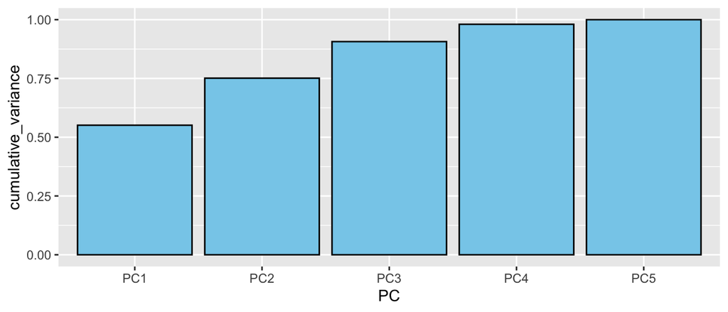

```r
library(broom)
Variance <- as_tibble(summary(pca_result)$importance)[3,]
Variance <- Variance %>%
  pivot_longer(everything(), names_to = "PC", values_to = "cumulative_variance")
ggplot(Variance, aes(x = PC, y = cumulative_variance)) +
  geom_col(fill = "skyblue", color = "black")
```

## We can use scatterplots and PCA to explore our data

Prepare data

```r
pc.dat <- bind_cols(PC1=pca_result$x[,1],
                    PC2=pca_result$x[,2],
                    PC3=pca_result$x[,3],
                    PC4=pca_result$x[,4],
                    PC5=pca_result$x[,5],
                    penguins)

colnames(pc.dat)
```

```
 [1] "PC1"               "PC2"               "PC3"
 [4] "PC4"               "PC5"               "species"
 [7] "island"            "bill_length_mm"    "bill_depth_mm"
[10] "flipper_length_mm" "body_mass_g"       "sex"
[13] "year"
```

## Run scatterplot

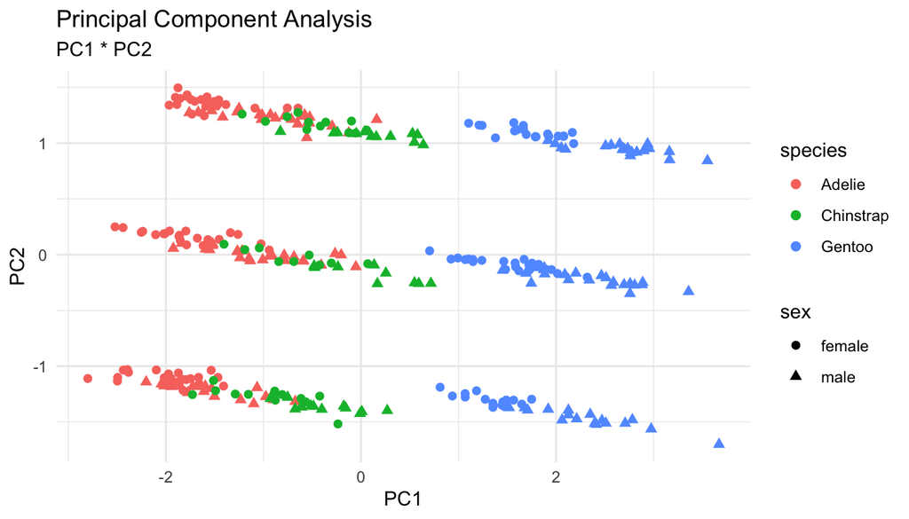

```r
ggplot(pc.dat, aes(x=PC1, y=PC2, col=species, shape=sex)) +
  geom_point(size=2) +
  ggtitle("Principal Component Analysis", subtitle="PC1 * PC2") + theme_minimal()
```

## Run scatterplot

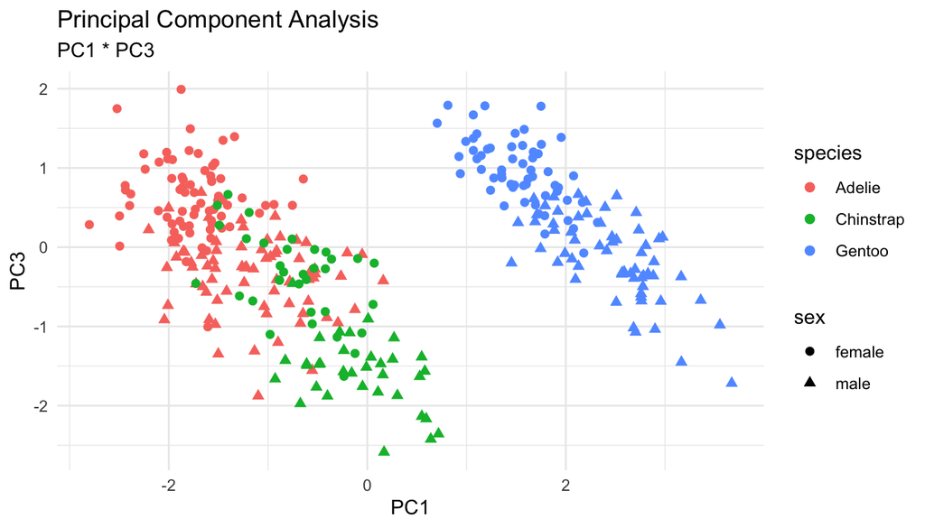

```r
ggplot(pc.dat, aes(x=PC1, y=PC3, col=species, shape=sex)) +
  geom_point(size=2) +
  ggtitle("Principal Component Analysis", subtitle="PC1 * PC3") + theme_minimal()
```

# Simple statistics

## t test

Is the difference in weight between Gentoo and Chinstrap penguins significant?

```r
gentoo <- penguins %>% filter(species=="Gentoo") %>% select(body_mass_g) %>% pull()
chinstrap <- penguins %>% filter(species=="Chinstrap") %>% select(body_mass_g) %>% pull()

t.test(gentoo, chinstrap,conf.level = 0.95)
```

```
    Welch Two Sample t-test

data:  gentoo and chinstrap
t = 20.765, df = 169.62, p-value < 2.2e-16
alternative hypothesis: true difference in means is not equal to 0
95 percent confidence interval:
 1230.120 1488.578
sample estimates:
mean of x mean of y
 5092.437  3733.088
```

## Fisher test

Are Adelie penguins overrepresented on the Biscoe island?

```r
adelie_biscoe <- penguins %>% filter(species=="Adelie" & island=="Biscoe") %>%
  rownames() %>% length()

others_biscoe <- penguins %>% filter(species!="Adelie" & island=="Biscoe") %>%
  rownames() %>% length()

adelie_other <- penguins %>% filter(species=="Adelie" & island!="Biscoe") %>%
  rownames() %>% length()

others_other <- penguins %>% filter(species!="Adelie" & island!="Biscoe") %>%
  rownames() %>% length()
```

## Fisher test

Are Adelie penguins overrepresented on the Biscoe island?

```r
data <- tibble(Adelie= c(adelie_biscoe, adelie_other),
               Others = c(others_biscoe, others_other)) %>%
  as.matrix()
rownames(data) <- c("Biscoe", "Other")
data
```

```
       Adelie Others
Biscoe     44    119
Other     102     68
```

## Fisher test

Are Adelie penguins overrepresented on the Biscoe island?

```r
fisher.test(data, alternative="greater")
```

```
    Fisher's Exact Test for Count Data

data:  data
p-value = 1
alternative hypothesis: true odds ratio is greater than 1
95 percent confidence interval:
 0.1629624       Inf
sample estimates:
odds ratio
 0.2476403
```

# For loops

## For loops

They are a way to repeat the same operation many times, iterating over the values of a vector.

They are not efficient in R, so if you have hundreds or thousands of elements you should look into the purrr package and learn concepts of functional programming (https://purrr.tidyverse.org/).

## For loops

```r
penguin_species <- penguins %>% select(species) %>% pull() %>% unique()
for (sp in penguin_species) {
  other_species <- penguins %>% select(species) %>% filter(!species==sp) %>% pull() %>% unique()
  sp2 <- other_species[1]
  sp3 <- other_species[2]

  data1 <- penguins %>% filter(species==sp) %>% select(body_mass_g) %>% pull()
  data2 <- penguins %>% filter(species==sp2) %>% select(body_mass_g) %>% pull()
  data3 <- penguins %>% filter(species==sp3) %>% select(body_mass_g) %>% pull()

  print(paste0(sp, " vs ", sp2))
  t.test(data1, data2,conf.level = 0.95) %>% print()
  print(paste0(sp, " vs ", sp3))
  t.test(data1, data3,conf.level = 0.95) %>% print()

}
```

## For loops

```
[1] "Adelie vs Gentoo"

    Welch Two Sample t-test

data:  data1 and data2
t = -23.254, df = 242.14, p-value < 2.2e-16
alternative hypothesis: true difference in means is not equal to 0
95 percent confidence interval:
 -1503.702 -1268.843
sample estimates:
mean of x mean of y
 3706.164  5092.437

[1] "Adelie vs Chinstrap"

    Welch Two Sample t-test

data:  data1 and data3
t = -0.44793, df = 154.03, p-value = 0.6548
alternative hypothesis: true difference in means is not equal to 0
95 percent confidence interval:
 -145.66494   91.81724
sample estimates:
mean of x mean of y
 3706.164  3733.088

[1] "Gentoo vs Adelie"

    Welch Two Sample t-test

data:  data1 and data2
t = 23.254, df = 242.14, p-value < 2.2e-16
alternative hypothesis: true difference in means is not equal to 0
95 percent confidence interval:
 1268.843 1503.702
sample estimates:
mean of x mean of y
 5092.437  3706.164

[1] "Gentoo vs Chinstrap"
```

[output cut: 22 more lines]

```
mean of x mean of y
 3733.088  3706.164

[1] "Chinstrap vs Gentoo"

    Welch Two Sample t-test

data:  data1 and data3
t = -20.765, df = 169.62, p-value < 2.2e-16
alternative hypothesis: true difference in means is not equal to 0
95 percent confidence interval:
 -1488.578 -1230.120
sample estimates:
mean of x mean of y
 3733.088  5092.437
```

## Nested for loops

```r
penguin_species <- penguins %>% select(species) %>% pull() %>% unique()
for (sp in penguin_species) {
  other_species <- penguins %>% select(species) %>% filter(!species==sp) %>% pull() %>% unique()
  for (sp2 in other_species) {
    data1 <- penguins %>% filter(species==sp) %>% select(body_mass_g) %>% pull()
    data2 <- penguins %>% filter(species==sp2) %>% select(body_mass_g) %>% pull()
    print(paste0(sp, " vs ", sp2))
    t.test(data1, data2,conf.level = 0.95) %>% print()
  }
}
```

Remember to adjust the pvalue if you run many tests.

## Exercises

- Try to rerun the previous code step by step, observe the obtained R objects and understand what we did.
- Work on your own dataset
- Run the following and follow the tutorial

```r
pak::pkg_install("UPSCb/Tutorial_01_data_science_intro")
learnr::run_tutorial("01_data_science_intro", package = "RnaSeqTutorial01")
```

## Interesting links

- Making interactive plots and apps with R (https://shiny.posit.co/r/getstarted/shiny-basics/lesson1/)
- Making presentations with quarto (https://quarto.org/docs/presentations/)
- Mixing R and python with reticulate (https://rstudio.github.io/reticulate/)
- Passing arguments to R scripts (https://www.r-bloggers.com/2015/09/passing-arguments-to-an-r-script-from-command-lines/)